**Instructor copy.** Executed notebook with all results shown, including the "after your attempt" cells. Projector/offline fallback; learners should use the notebook itself.

# f4b · One phase diagram from scratch, then with pycalphad

**Learning question:** what does a CALPHAD program actually do when it "calculates an equilibrium"? We find out by doing every step ourselves for one small problem, with nothing but numpy and SciPy, and then let pycalphad solve the same problem and compare the numbers.

**The problem.** Two invented components, A and B, can each be SOLID or LIQUID. In both phases A and B mix freely (an *ideal solution*). We ask:

1. At 1400 K, for a sample with overall B atom fraction z = 0.40: is it solid, liquid, or a mixture of both? If a mixture: which compositions, and how much of each?
2. Repeating that at many temperatures: what does the phase diagram look like?

**The route.** Each section adds one idea, and every line of code is visible:

| Section | What we do | Tool |
| --- | --- | --- |
| 1 | Gibbs energy of the pure components | plain Python |
| 2 | Gibbs energy of each phase as a function of composition | numpy |
| 3 | Try every possible split of the sample into SOLID + LIQUID | numpy (brute force) |
| 4 | The condition for the best split: equal chemical potentials | `scipy.optimize.fsolve` |
| 5 | How CALPHAD programs search: a grid and a linear programme | `scipy.optimize.linprog` |
| 6 | Repeat at many temperatures: the phase diagram | numpy loop |
| 7 | The same model as a database, solved by pycalphad | pycalphad |
| 8 | Compare: what pycalphad did for us | — |

**Before you start.** You need the idea that a system at fixed temperature and pressure ends up in the state of lowest Gibbs energy (f0 and f1 introduce it). Everything else is explained here. f4 meets the same melting lens in its part C; this notebook builds it up one step at a time and then hands it to pycalphad.

**How to work.** Run the cells from top to bottom. In each "Your turn" cell, work the answer out (on paper or with code in the cell), replace `None` with your value and run the cell: it tells you whether you match, without showing the answer.

```python
# Setup: run this cell first. Locally it finds the course folder; in Colab it
# downloads the tested course release and the locked package versions.
# In Colab, the first run then restarts the session on purpose and Colab reports
# a crash: that is expected. Run this cell again, then the rest of the notebook.
RELEASE = "main"
import os, pathlib, subprocess, sys, time
ROOT = next((p for p in (pathlib.Path.cwd(), *pathlib.Path.cwd().parents)
             if (p / "pyproject.toml").is_file() and (p / "course").is_dir()), None)
if ROOT is None and "google.colab" in sys.modules:
    ROOT = pathlib.Path("/content/CalphadIntro")
    if not ROOT.is_dir():
        clone = ["git", "clone", "-q", "--depth", "1", "--branch", RELEASE,
                 "https://github.com/ukerzel/CalphadIntro.git", str(ROOT)]
        git = dict(os.environ, GIT_TERMINAL_PROMPT="0")
        if subprocess.run(clone, env=git, capture_output=True).returncode:
            raise SystemExit(f"Could not download course release {RELEASE}: check the internet "
                             "connection and run this cell again.")
    if not (ROOT / ".colab-ready").exists():
        if subprocess.run([sys.executable, "-m", "pip", "install", "-q", "-r",
                           str(ROOT / "notebooks" / "requirements-colab.txt")]).returncode:
            raise SystemExit("Installing the course packages failed; run this cell again.")
        (ROOT / ".colab-ready").touch()
        # Colab has already loaded its own numpy; a fresh session is needed to use the installed versions.
        print("Installed the course's package versions. Colab now restarts this session and"
              " reports a crash; that is expected. When it has reconnected, run this cell again"
              " (it will not install twice), then the rest of the notebook.", flush=True)
        time.sleep(3)
        os.kill(os.getpid(), 9)
if ROOT is None:
    raise SystemExit("Open this notebook from the course folder (poetry run jupyter lab) or in Colab.")
os.chdir(ROOT)
sys.path.insert(0, str(ROOT))
from notebooks.helpers import check, confirm, database, show_versions
show_versions(RELEASE)
```

```
Course release main · Python 3.12.14
  numpy       2.5.3
  scipy       1.18.1
  matplotlib  3.11.2
  xarray      2026.7.0
  pycalphad   0.11.2
```

```
True
```

## 0. Tools and units

We use three libraries:

- **numpy** (`np`): arrays of numbers and fast arithmetic on whole arrays at once. `np.log(x)` works on a single number or on an array of a thousand numbers.
- **SciPy** (`scipy.optimize`): ready-made solvers. We use two of them: one that solves equations (`fsolve`) and one that minimises a linear function under constraints (`linprog`).
- **matplotlib** (`plt`): plots.

Units throughout: temperature T in K, energies in J per mole of atoms (J/mol), entropies in J/(mol K), compositions as B atom fractions between 0 and 1. The gas constant is R = 8.3145 J/(mol K), the value pycalphad uses, so that our numbers and pycalphad's can agree to many digits in section 7.

```python
import numpy as np                      # arrays and maths on arrays
import matplotlib.pyplot as plt         # plotting
from scipy.optimize import fsolve, linprog   # an equation solver and a linear-programme solver

R = 8.3145   # gas constant, J/(mol K)
```

## 1. The pure components

For a pure component in one phase we use the simplest possible model: a constant enthalpy h and a constant entropy s, so its molar Gibbs energy is a straight line in T:

$$g^\circ(T) = h - T\,s .$$

| Component | SOLID: h (J/mol), s (J/(mol K)) | LIQUID: h, s |
| --- | --- | --- |
| A | 1000, 10 | 7000, 16 |
| B | 2000, 10 | 20000, 20 |

The liquid has the higher enthalpy (melting needs heat) and the higher entropy (the liquid is more disordered). At low T the −Ts term is small, so the lower h wins: SOLID. At high T the −Ts term dominates, so the higher s wins: LIQUID. The melting temperature is where the two lines cross.

Below we store the numbers in two nested dictionaries: `H["B"]["LIQUID"]` reads "the enthalpy of B in the LIQUID phase". The function `g0` then evaluates h − Ts for any component, phase and temperature.

```python
H = {"A": {"SOLID": 1000.0, "LIQUID": 7000.0},     # J/mol
     "B": {"SOLID": 2000.0, "LIQUID": 20000.0}}
S = {"A": {"SOLID": 10.0, "LIQUID": 16.0},          # J/(mol K)
     "B": {"SOLID": 10.0, "LIQUID": 20.0}}

def g0(component, phase, T):
    """Molar Gibbs energy of a pure component in one phase, J/mol."""
    return H[component][phase] - T * S[component][phase]

# Try it: pure A at 1000 K in both phases.
print("A at 1000 K: SOLID", g0("A", "SOLID", 1000.0), "J/mol, LIQUID", g0("A", "LIQUID", 1000.0), "J/mol")
```

```
A at 1000 K: SOLID -9000.0 J/mol, LIQUID -9000.0 J/mol
```

Both values are −9000 J/mol: at 1000 K solid and liquid A have the same Gibbs energy, so **A melts at 1000 K**. In general the lines cross where h_S − T s_S = h_L − T s_L, that is at

$$T_m = \frac{h_L - h_S}{s_L - s_S}.$$

### Your turn: the melting temperature of B

Use the table above. Give T_m of pure B in K.

```python
T_melt_B = None   # K
check(T_melt_B, "f4b_tm_B")
```

```
f4b_tm_B: not attempted yet. Replace None with your value and run the cell again.
```

So B melts higher than A. Between the two melting temperatures we expect something in between: alloys that are partly solid and partly liquid.

## 2. One phase, any composition

Now mix the two components in one phase. Take one mole of atoms with B atom fraction x (so 1 − x mol of A and x mol of B). For an **ideal solution** the Gibbs energy per mole of atoms has two parts:

$$g_\varphi(x, T) = \underbrace{(1-x)\,g^\circ_{A,\varphi}(T) + x\,g^\circ_{B,\varphi}(T)}_{\text{weighted average of the pure components}} \;+\; \underbrace{R T\,[\,x\ln x + (1-x)\ln(1-x)\,]}_{\text{ideal mixing}} .$$

- The first part is a straight line between pure A (x = 0) and pure B (x = 1): just the two unmixed components side by side.
- The second part comes from the configurational entropy of placing A and B atoms randomly: $-T\,\Delta s_{\rm mix}$ with $\Delta s_{\rm mix} = -R\,[x\ln x + (1-x)\ln(1-x)]$. Because ln of a number between 0 and 1 is negative, this part is always ≤ 0: mixing lowers g. It is zero at the pure ends and most negative at x = 0.5.
- "Ideal" means there is no extra energy for A–B neighbours compared with A–A and B–B (no interaction term). f4 part B adds such a term (the regular solution, with interaction parameter Ω).

φ stands for either phase: SOLID or LIQUID use the same formula with their own g° values.

In code, `g_phase` takes x as a single number **or** a numpy array; numpy applies the formula to every element of the array. The formula needs 0 < x < 1 because ln 0 is undefined (the mixing term goes to 0 at the ends, but the computer cannot evaluate 0 · ln 0 directly), so we keep x away from the ends.

The cell also makes `x_grid`, an array of 999 compositions that later sections reuse. In "Your turn" cells, use new names for your own values (as the cells suggest), so that `x_grid`, `T`, `z` and the other results stay as they are.

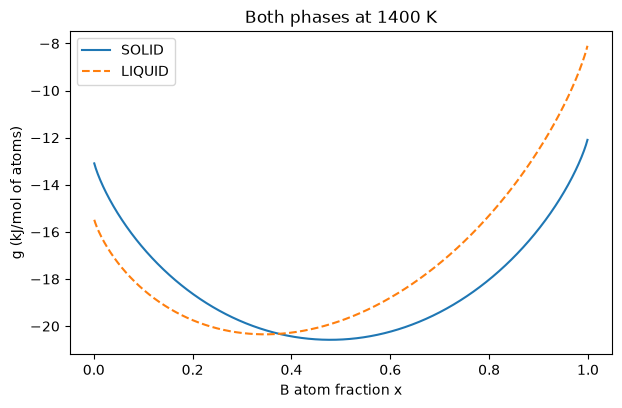

```python
def g_phase(phase, x, T):
    """Molar Gibbs energy of an ideal A–B solution in `phase`, J/mol of atoms. Needs 0 < x < 1."""
    pure = (1 - x) * g0("A", phase, T) + x * g0("B", phase, T)   # straight line between the pure ends
    mixing = R * T * (x * np.log(x) + (1 - x) * np.log(1 - x))  # ideal mixing, always ≤ 0
    return pure + mixing

T = 1400.0   # K, the temperature of our question
x_grid = np.linspace(0.001, 0.999, 999)   # 999 compositions from 0.001 to 0.999, spacing 0.001

plt.figure(figsize=(7, 4.2))
plt.plot(x_grid, g_phase("SOLID", x_grid, T) / 1000, label="SOLID")       # / 1000: plot in kJ/mol
plt.plot(x_grid, g_phase("LIQUID", x_grid, T) / 1000, "--", label="LIQUID")
plt.xlabel("B atom fraction x")
plt.ylabel("g (kJ/mol of atoms)")
plt.title(f"Both phases at {T:.0f} K")
plt.legend()
plt.show()
```

**Reading the plot.** At 1400 K pure A is above its melting point, so on the left (A-rich) the LIQUID curve is lower. Pure B is below its melting point, so on the right (B-rich) the SOLID curve is lower. The curves cross somewhere in between. A sample that is A-rich enough is liquid, one that is B-rich enough is solid. What happens in between is the subject of the next two sections.

### Your turn: one point on each curve

Our sample has z = 0.40. Compute g of **homogeneous** SOLID and of homogeneous LIQUID at x = 0.40 and 1400 K (J/mol, four significant figures). You may type the arithmetic by hand or call `g_phase`. Which phase is lower on its own?

```python
g_solid_040 = None    # J/mol
g_liquid_040 = None   # J/mol
check(g_solid_040, "f4b_g_solid_040")
check(g_liquid_040, "f4b_g_liquid_040")
```

```
f4b_g_solid_040: not attempted yet. Replace None with your value and run the cell again.
f4b_g_liquid_040: not attempted yet. Replace None with your value and run the cell again.
```

## 3. Splitting the sample: try every possibility

A sample does not have to be one phase. It may split into a SOLID region with composition $x_S$ and a LIQUID region with composition $x_L$. Two bookkeeping rules fix how much of each forms. With $f_S$ and $f_L$ the mole fractions of atoms in each region:

$$f_S + f_L = 1 \quad\text{(all atoms are somewhere)},\qquad f_S\,x_S + f_L\,x_L = z \quad\text{(all B atoms are somewhere)}.$$

Solving these two equations gives the **lever rule**:

$$f_L = \frac{z - x_S}{x_L - x_S},\qquad f_S = 1 - f_L .$$

A split is physically possible only if both amounts lie between 0 and 1, which happens when z lies between $x_S$ and $x_L$. The Gibbs energy of the split sample is the amount-weighted sum of the two regions:

$$G_{\rm split} = f_S\,g_S(x_S) + f_L\,g_L(x_L).$$

The equilibrium state is the one with the lowest G. The most direct way to find it: **try every pair** $(x_S, x_L)$ on a grid, keep the possible ones, and pick the lowest. With 999 trial compositions per phase that is about a million pairs, which numpy handles in a second.

Two numpy tools do the work:

- `np.meshgrid(a, b, indexing="ij")` makes two 2-D arrays so that element `[i, j]` holds `a[i]` and `b[j]`: every combination of a SOLID and a LIQUID composition.
- `np.where(condition, value, other)` picks `value` where the condition holds and `other` elsewhere; we give impossible splits the energy +∞ so they never win. `np.argmin` then finds the position of the smallest value.

```python
def lever_liquid(z, x_solid, x_liquid):
    """Amount fraction of LIQUID from the lever rule (atoms in LIQUID / all atoms)."""
    return (z - x_solid) / (x_liquid - x_solid)

z = 0.40   # overall B atom fraction of the sample

XS, XL = np.meshgrid(x_grid, x_grid, indexing="ij")   # XS[i, j] = x_grid[i] (SOLID), XL[i, j] = x_grid[j] (LIQUID)
with np.errstate(divide="ignore", invalid="ignore"):   # x_S = x_L divides by 0; those pairs are dropped
    fL = lever_liquid(z, XS, XL)
    possible = (XS != XL) & (fL >= 0) & (fL <= 1)    # both amounts between 0 and 1
    G_split = np.where(possible, (1 - fL) * g_phase("SOLID", XS, T) + fL * g_phase("LIQUID", XL, T), np.inf)

i, j = np.unravel_index(np.argmin(G_split), G_split.shape)   # argmin counts through the table as one long list;
                                                             # unravel_index turns that count into (row, column)
print(f"best pair on the grid: x_S = {x_grid[i]:.3f}, x_L = {x_grid[j]:.3f}, f_L = {fL[i, j]:.4f}")
print(f"G of the best split:     {G_split[i, j]:.3f} J/mol")
print(f"homogeneous SOLID:       {g_phase('SOLID', z, T):.3f} J/mol")
print(f"homogeneous LIQUID:      {g_phase('LIQUID', z, T):.3f} J/mol")
```

```
best pair on the grid: x_S = 0.441, x_L = 0.312, f_L = 0.3178
G of the best split:     -20473.119 J/mol
homogeneous SOLID:       -20434.058 J/mol
homogeneous LIQUID:      -20274.058 J/mol
```

**Reading the output.** The split into a B-rich SOLID and an A-rich LIQUID is lower than either phase alone, so at 1400 K our z = 0.40 sample is partly solid and partly liquid. The brute-force answer is only as fine as the grid (here 0.001 in x).

### Your turn: how much lower?

By how many J/mol is the best split lower than the better of the two homogeneous phases? Give a positive number (four significant figures are enough; the grid answer is close enough).

```python
split_lower_by = None   # J/mol, positive
check(split_lower_by, "f4b_split_lower_by")
```

```
f4b_split_lower_by: not attempted yet. Replace None with your value and run the cell again.
```

## 4. The condition for the best split: equal chemical potentials

Brute force works for one temperature and two phases, but real programs need something sharper. Draw the straight line through the two points $(x_S, g_S(x_S))$ and $(x_L, g_L(x_L))$: $G_{\rm split}$ is the height of that line at x = z. The lowest such line is the one that just touches both curves from below, the **common tangent**. At the touching points the two curves have the same slope, and the tangent line meets x = 0 and x = 1 at the same heights for both phases.

The heights of a tangent at x = 0 and x = 1 are the **chemical potentials** μ_A and μ_B. For any curve g(x):

$$\mu_A = g - x\,\frac{dg}{dx},\qquad \mu_B = g + (1-x)\,\frac{dg}{dx}.$$

So the equilibrium condition is two equations in two unknowns:

$$\mu_{A}^{\rm SOLID}(x_S) = \mu_{A}^{\rm LIQUID}(x_L),\qquad \mu_{B}^{\rm SOLID}(x_S) = \mu_{B}^{\rm LIQUID}(x_L).$$

For our ideal solutions the derivative is easy and the result is short (try it on paper: differentiate g_phase and insert):

$$\mu_{A}^{\varphi} = g^\circ_{A,\varphi} + RT\ln(1-x),\qquad \mu_{B}^{\varphi} = g^\circ_{B,\varphi} + RT\ln x .$$

First we check this formula against a numerical slope of g, so we don't have to take it on trust. `np.gradient(g, x)` estimates dg/dx at every grid point from the neighbouring points.

```python
def mu_phase(phase, x, T):
    """(mu_A, mu_B) of an ideal solution in `phase` at B atom fraction x, J/mol."""
    mu_A = g0("A", phase, T) + R * T * np.log(1 - x)
    mu_B = g0("B", phase, T) + R * T * np.log(x)
    return mu_A, mu_B

g_S = g_phase("SOLID", x_grid, T)
slope = np.gradient(g_S, x_grid)                 # numerical dg/dx, J/mol per unit x
mu_A_numeric = g_S - x_grid * slope          # tangent height at x = 0
mu_B_numeric = g_S + (1 - x_grid) * slope    # tangent height at x = 1
mu_A_formula, mu_B_formula = mu_phase("SOLID", x_grid, T)
k = 400                                     # look at one grid point, x = 0.401
print(f"x = {x_grid[k]:.3f}: mu_A numeric {mu_A_numeric[k]:.2f}, formula {mu_A_formula[k]:.2f} J/mol")
print(f"          mu_B numeric {mu_B_numeric[k]:.2f}, formula {mu_B_formula[k]:.2f} J/mol")
```

```
x = 0.401: mu_A numeric -18965.58, formula -18965.58 J/mol
          mu_B numeric -22636.84, formula -22636.83 J/mol
```

The numerical slope and the formula agree to a small fraction of a J/mol (the difference comes from estimating the slope from neighbouring points).

**Solving the two equations.** `fsolve(f, guess)` looks for the values that make every entry of `f(...)` zero. We write a function that takes the two unknowns `[x_S, x_L]` and returns the two differences μ(SOLID) − μ(LIQUID). Like most equation solvers, `fsolve` starts from a guess and improves it step by step, so it needs a reasonable starting point: we use the brute-force pair from section 3.

```python
def mu_difference(unknowns, T):
    """The two equilibrium conditions; both entries are 0 at the common tangent."""
    x_S, x_L = unknowns
    mu_A_S, mu_B_S = mu_phase("SOLID", x_S, T)
    mu_A_L, mu_B_L = mu_phase("LIQUID", x_L, T)
    return [mu_A_S - mu_A_L, mu_B_S - mu_B_L]

guess = [x_grid[i], x_grid[j]]               # start from the brute-force answer
x_S, x_L = fsolve(mu_difference, guess, args=(T,))   # args passes T on to mu_difference
f_L = lever_liquid(z, x_S, x_L)
f_S = 1 - f_L
G_best = f_S * g_phase("SOLID", x_S, T) + f_L * g_phase("LIQUID", x_L, T)

print(f"x_S = {x_S:.6f}, x_L = {x_L:.6f}")
residual = mu_difference([x_S, x_L], T)
print(f"remaining mu differences: {residual[0]:.1e}, {residual[1]:.1e} J/mol")
print(f"f_S = {f_S:.6f}, f_L = {f_L:.6f}, G = {G_best:.4f} J/mol")
print("checks: f_S + f_L =", f_S + f_L, "| B balance f_S x_S + f_L x_L =", f_S * x_S + f_L * x_L)
```

```
x_S = 0.440517, x_L = 0.312410
remaining mu differences: -4.9e-09, -1.6e-08 J/mol
f_S = 0.683725, f_L = 0.316275, G = -20473.1242 J/mol
checks: f_S + f_L = 1.0 | B balance f_S x_S + f_L x_L = 0.4
```

The remaining differences are tiny (well below 1e-6 J/mol): the equations are solved. The two balance checks give back 1 and z = 0.40, and G is slightly lower than the best brute-force pair because x_S and x_L are no longer limited to the grid.

The touching points are called the **solidus** composition (x_S, the solid that can coexist with liquid) and the **liquidus** composition (x_L).

### Your turn: the amounts

What fraction of the atoms is in the LIQUID at 1400 K? Then find out what happens at 1600 K. Solve again at 1600 K, using new variable names so the 1400 K values stay as they are: `x_S_1600, x_L_1600 = fsolve(mu_difference, [x_S, x_L], args=(1600.0,))`. Compute `f_L_1600 = lever_liquid(z, x_S_1600, x_L_1600)` and decide which phase the z = 0.40 sample is at 1600 K: `"SOLID"`, `"LIQUID"` or `"both"`. (Hint: what does an amount below 0 or above 1 tell you?)

```python
liquid_fraction_1400 = None   # between 0 and 1
phase_at_1600 = None          # "SOLID", "LIQUID" or "both"
check(liquid_fraction_1400, "f4b_f_liquid_1400")
check(phase_at_1600, "f4b_phase_1600")
```

```
f4b_f_liquid_1400: not attempted yet. Replace None with your value and run the cell again.
```

```
f4b_phase_1600: not attempted yet. Replace None with your value and run the cell again.
```

## 5. How CALPHAD programs search: a grid and a linear programme

Section 4 needed a good starting guess, and it assumed we already knew that the answer is SOLID + LIQUID. A program for real alloys cannot assume either: there may be ten phases, and a bad guess can lead an equation solver to the wrong answer. CALPHAD programs therefore work in two stages:

1. **Global stage.** Sample every phase at many compositions. Each sample is a candidate region with a known g. Find the amounts $f_k \ge 0$ of the candidates that give the lowest total energy while keeping all atoms and all B atoms: minimise $\sum_k f_k g_k$ subject to $\sum_k f_k = 1$ and $\sum_k f_k x_k = z$. The objective and both constraints are *linear* in the unknown amounts, so this is a **linear programme**, which has a reliable solver that needs no starting guess. Its answer is global only over the sampled points: a state between them can still be lower.
2. **Local stage.** Use the best candidates as the starting guess for the equations of section 4 and refine.

`linprog(c, A_eq=..., b_eq=..., bounds=...)` minimises `c @ f` (the sum of c[k] f[k]) subject to `A_eq @ f = b_eq` and the bounds. Our `c` is the list of candidate energies, the two rows of `A_eq` are "1 for every candidate" (total amount) and "x of every candidate" (B balance), and `b_eq = [1, z]`.

```python
grid = np.linspace(0.001, 0.999, 201)                     # 201 trial compositions per phase
candidate_x = np.concatenate([grid, grid])                 # SOLID candidates, then LIQUID candidates
candidate_g = np.concatenate([g_phase("SOLID", grid, T), g_phase("LIQUID", grid, T)])   # J/mol
candidate_phase = ["SOLID"] * len(grid) + ["LIQUID"] * len(grid)

result = linprog(candidate_g,
                 A_eq=[np.ones_like(candidate_x), candidate_x],   # total amount, B balance
                 b_eq=[1.0, z],
                 bounds=(0, None),                                 # amounts cannot be negative
                 method="highs")
print("solver finished:", result.success)
for k in np.flatnonzero(result.x > 1e-9):                          # candidates with a non-zero amount
    print(f"  {candidate_phase[k]:6s} x = {candidate_x[k]:.4f}  amount = {result.x[k]:.4f}")
print(f"grid energy {result.fun:.4f} J/mol (best split from section 4: {G_best:.4f})")
```

```
solver finished: True
  SOLID  x = 0.4401  amount = 0.6908
  LIQUID x = 0.3104  amount = 0.3092
grid energy -20473.0871 J/mol (best split from section 4: -20473.1242)
```

The linear programme picks one SOLID and one LIQUID candidate, each a grid point next to the true touching point, and gives an energy just above the exact one: a feasible split on a grid can never be lower than the true minimum. It found this without any guess and without being told which phases appear.

Now the local stage: start `fsolve` from the two chosen candidates.

```python
chosen = np.flatnonzero(result.x > 1e-9)
start = {candidate_phase[k]: candidate_x[k] for k in chosen}       # a dict built in one line: {"SOLID": x, "LIQUID": x}
refined = fsolve(mu_difference, [start["SOLID"], start["LIQUID"]], args=(T,))
print(f"grid start: x_S = {start['SOLID']:.4f}, x_L = {start['LIQUID']:.4f}"
      f"  →  refined: x_S = {refined[0]:.6f}, x_L = {refined[1]:.6f}")
```

```
grid start: x_S = 0.4401, x_L = 0.3104  →  refined: x_S = 0.440517, x_L = 0.312410
```

Same answer as section 4, now reached the way a CALPHAD program reaches it.

**What the linear programme also returns.** Besides the amounts, `linprog` returns one multiplier per equation in `result.eqlin.marginals`: how much the minimum changes when that equation's right-hand side changes a little, while the same candidates stay in use. For our two rows (total amount, B balance) they are the height μ_A of a straight line at x = 0 and its slope μ_B − μ_A: a line through the two chosen candidates and under all the others. They are the grid's chemical potentials, close to the exact ones of section 4.

```python
mu_A_grid, d_mu_grid = result.eqlin.marginals              # line height at x = 0, slope mu_B − mu_A
mu_exact = mu_phase("SOLID", refined[0], T)                # exact (mu_A, mu_B) at the refined split
print(f"grid line: mu_A = {mu_A_grid:.2f}, mu_B = {mu_A_grid + d_mu_grid:.2f} J/mol")
print(f"exact:     mu_A = {mu_exact[0]:.2f}, mu_B = {mu_exact[1]:.2f} J/mol")
assert abs(mu_A_grid + d_mu_grid * z - result.fun) < 1e-6, "the line should pass through the grid answer at z"
```

```
grid line: mu_A = -19759.65, mu_B = -21543.25 J/mol
exact:     mu_A = -19760.02, mu_B = -21542.79 J/mol
```

The advanced steps build on these two numbers: the line under the candidates, what it promises, and what it does not (notebook f4c).

## 6. Many temperatures: the phase diagram

A binary phase diagram shows, for every temperature, which compositions are single-phase and which split. For our two phases that means: at each T between the melting points of A (1000 K) and B (1800 K), solve for x_S and x_L. Plotted against T, the x_S values form the **solidus** line and the x_L values the **liquidus** line. Above the liquidus everything is LIQUID, below the solidus everything is SOLID, and in between the sample splits.

We already know the answer at 1400 K. From there we walk up in 10 K steps to 1790 K and down to 1010 K, each time using the previous answer as the starting guess for `fsolve`. Neighbouring temperatures have nearly the same answer, so the guess is always close (this is called *continuation*).

For ideal solutions the two equations can also be solved on paper (f4 part C shows how). The closed form is a good independent check of the numerical loop: with $a = e^{(g^\circ_{A,S}-g^\circ_{A,L})/RT}$ and $b = e^{(g^\circ_{B,S}-g^\circ_{B,L})/RT}$, $x_S = (1-a)/(b-a)$ and $x_L = b\,x_S$.

```
79 temperatures from 1010 to 1790 K; largest difference to the closed form: 7.2e-12
```

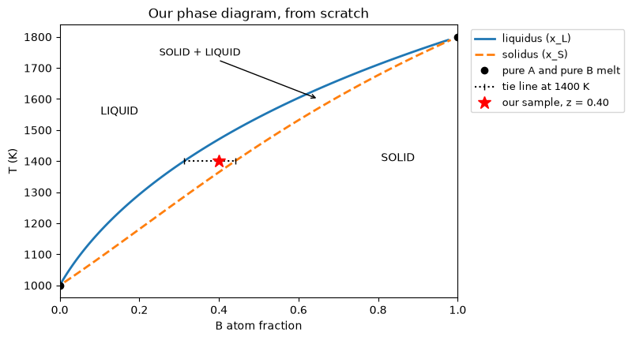

```python
def walk(temperatures, guess):
    """Solve for (x_S, x_L) at each temperature in turn, starting each solve from the previous answer."""
    rows = []
    for T_i in temperatures:
        guess = fsolve(mu_difference, guess, args=(T_i,))
        rows.append((T_i, guess[0], guess[1]))
    return rows

up = walk(np.arange(1400.0, 1800.0, 10.0), [x_S, x_L])     # 1400 → 1790 K
down = walk(np.arange(1390.0, 1000.0, -10.0), [x_S, x_L])  # 1390 → 1010 K
lens = np.array(sorted(down + up))                           # columns: T, x_S, x_L; sorted by T
# lens[:, 0] is the T column (":" means all rows), lens[:, 1:] the x_S and x_L columns

def closed_form(T):
    """x_S and x_L of the ideal lens from the formulas above."""
    a = np.exp((g0("A", "SOLID", T) - g0("A", "LIQUID", T)) / (R * T))
    b = np.exp((g0("B", "SOLID", T) - g0("B", "LIQUID", T)) / (R * T))
    x_solidus = (1 - a) / (b - a)
    return x_solidus, b * x_solidus

exact = np.array([closed_form(T_i) for T_i in lens[:, 0]])
print(f"{len(lens)} temperatures from {lens[0, 0]:.0f} to {lens[-1, 0]:.0f} K;",
      f"largest difference to the closed form: {np.abs(lens[:, 1:] - exact).max():.1e}")

fig, ax = plt.subplots(figsize=(6.5, 4.5))
ax.plot(lens[:, 2], lens[:, 0], "-", lw=2, label="liquidus (x_L)")
ax.plot(lens[:, 1], lens[:, 0], "--", lw=2, label="solidus (x_S)")
ax.plot([0, 1], [1000, 1800], "ko", label="pure A and pure B melt")
ax.plot([x_L, x_S], [1400, 1400], "k:|", label="tie line at 1400 K")
ax.plot([z], [1400], "r*", ms=12, label="our sample, z = 0.40")
ax.text(0.15, 1550, "LIQUID", ha="center")
ax.text(0.85, 1400, "SOLID", ha="center")
ax.annotate("SOLID + LIQUID", xy=(0.65, 1600), xytext=(0.25, 1740), fontsize=9,
            arrowprops=dict(arrowstyle="->"))   # text at xytext, arrow pointing into the lens at xy
ax.set(xlabel="B atom fraction", ylabel="T (K)", xlim=(0, 1), title="Our phase diagram, from scratch")
ax.legend(fontsize=9, loc="upper left", bbox_to_anchor=(1.02, 1))   # legend outside, right of the plot
plt.show()
```

**Reading the diagram.** This shape is called a **lens**. The horizontal dotted line at 1400 K is a **tie line**: its ends are x_L (left) and x_S (right), and our sample (red star) lies on it, so it splits into those two compositions, with amounts from the lever rule. The closer the star is to one end, the more of that phase. Heat the sample and the star moves up out of the lens into LIQUID; cool it and it moves down into SOLID. That is what you found at 1600 K in section 4.

The loop and the closed form agree to about 1e-11, so the numerical route is right.

### Your turn: read the diagram

Find the liquidus composition x_L at 1600 K, either with `closed_form(1600.0)` or from the table: `lens[lens[:, 0] == 1600]` keeps the rows whose first column (T) equals 1600. Is the SOLID that coexists with this liquid richer or poorer in B? Answer `"richer"` or `"poorer"`.

```python
x_liquidus_1600 = None   # B atom fraction
solid_is = None          # "richer" or "poorer" in B than the liquid
check(x_liquidus_1600, "f4b_x_liquidus_1600")
check(solid_is, "f4b_solid_richer")
```

```
f4b_x_liquidus_1600: not attempted yet. Replace None with your value and run the cell again.
f4b_solid_richer: not attempted yet. Replace None with your value and run the cell again.
```

## 7. The same problem in pycalphad

So far we wrote three things ourselves: the **model** (g0, g_phase), the **search** (grid, linear programme, equation solver) and the **diagram** (the loop over T). In a CALPHAD program the model lives in a **database file** (TDB format) and the program does the search and the diagram.

Here is our model as a TDB. Each line ends with `!`:

- `ELEMENT A BLANK 1.0 0.0 0.0` declares a component. The extra fields (reference phase, mass and two reference enthalpy/entropy values) are not used here, so they are placeholders.
- `TYPE_DEFINITION % SEQ *` is a standard line that most TDB files carry. It defines the type code `%`, which the `PHASE` lines below refer to; it says the phases use no special options.
- `PHASE SOLID % 1 1` declares a phase with one sublattice holding 1 site per formula unit (one atom per "mole of formula units", so per mole of atoms).
- `CONSTITUENT SOLID :A,B:` says A and B can both occupy that sublattice. The site fraction of B is then simply x.
- `PARAMETER G(SOLID,A;0) 300 1000-10*T; 3000 N` is $g^\circ$ of pure A in SOLID: h − T s with our numbers, valid from 300 K to 3000 K (`N` ends the list of temperature ranges).

What is **not** in the file: the ideal mixing term RT[x ln x + (1−x) ln(1−x)]. pycalphad adds it automatically for every sublattice that holds more than one constituent (weighted by the sublattice's number of sites; here one sublattice with 1 site, so exactly our term). An interaction term (as in f4 part B's regular solution) would be one more line, `PARAMETER L(SOLID,A,B;0) ...`; leaving it out makes the solution ideal.

```python
from pycalphad import Database, binplot, equilibrium, variables as v

LENS_TDB = """
ELEMENT A BLANK 1.0 0.0 0.0 !
ELEMENT B BLANK 1.0 0.0 0.0 !
TYPE_DEFINITION % SEQ * !
PHASE SOLID % 1 1 !
CONSTITUENT SOLID :A,B: !
PARAMETER G(SOLID,A;0) 300 1000-10*T; 3000 N !
PARAMETER G(SOLID,B;0) 300 2000-10*T; 3000 N !
PHASE LIQUID % 1 1 !
CONSTITUENT LIQUID :A,B: !
PARAMETER G(LIQUID,A;0) 300 7000-16*T; 3000 N !
PARAMETER G(LIQUID,B;0) 300 20000-20*T; 3000 N !
"""
db = Database(LENS_TDB)        # Database() reads a file name or, as here, the TDB text itself
print("phases in the database:", sorted(db.phases))
```

```
phases in the database: ['LIQUID', 'SOLID']
```

**Asking for the equilibrium.** `equilibrium(db, components, phases, conditions)` does sections 3–5 for us. The conditions fix the state: temperature `v.T`, pressure `v.P` (Pa), total amount `v.N` (1 mol of atoms) and overall composition `v.X("B")` (our z). Like us, pycalphad first samples every phase on a grid and then refines the best candidates by solving the equilibrium equations.

The result is an *xarray Dataset*: a set of named arrays with labelled axes. For one set of conditions the interesting ones are, after `.squeeze()` (which drops the axes of length 1, here N, P, T and X_B):

- `Phase`: the names of the phases present, one per **vertex** (a vertex is one region of the split; unused vertices are empty strings);
- `NP`: the amount of each region (our f_L, f_S; NaN for unused vertices);
- `X`: the composition of each region, with an axis `component` (A, B); `.sel(component="B")` picks the B column, our x_S and x_L;
- `GM`: the Gibbs energy of the whole sample per mole of atoms (our G);
- `MU`: the chemical potentials μ_A and μ_B, the same in every region.

```python
eq = equilibrium(db, ["A", "B"], ["SOLID", "LIQUID"],
                 {v.T: 1400, v.P: 100000, v.N: 1, v.X("B"): 0.40})
phases = eq.Phase.values.squeeze()                        # e.g. ['LIQUID' 'SOLID' '']
amounts = eq.NP.values.squeeze()                          # amount of each region
x_B = eq.X.sel(component="B").values.squeeze()            # B atom fraction of each region
print("pycalphad at 1400 K, z = 0.40")
for name, amount, xb in zip(phases, amounts, x_B):              # zip walks through the three arrays side by side
    if name:                                              # skip unused (empty) vertices
        print(f"  {name:6s} amount {amount:.6f}  x_B {xb:.6f}")
print(f"  GM = {float(eq.GM.values.squeeze()):.4f} J/mol, MU (A, B) = {eq.MU.values.squeeze()} J/mol")
```

```
pycalphad at 1400 K, z = 0.40
  LIQUID amount 0.316275  x_B 0.312410
  SOLID  amount 0.683725  x_B 0.440517
  GM = -20473.1242 J/mol, MU (A, B) = [-19760.01668937 -21542.78551145] J/mol
```

**Side by side.** The table puts our from-scratch numbers next to pycalphad's. We look the phases up by name, because pycalphad does not promise any order of the vertices.

```python
pyc = {name: (amount, xb) for name, amount, xb in zip(phases, amounts, x_B) if name}   # {phase name: (amount, x_B)}, used vertices only
G_pycalphad = float(eq.GM.values.squeeze())
mu_ours = mu_phase("SOLID", x_S, T)
rows = [("x_S (SOLID composition)", x_S, pyc["SOLID"][1]),
        ("x_L (LIQUID composition)", x_L, pyc["LIQUID"][1]),
        ("f_L (LIQUID amount)", f_L, pyc["LIQUID"][0]),
        ("G (J/mol)", G_best, G_pycalphad),
        ("mu_A (J/mol)", mu_ours[0], float(eq.MU.sel(component="A").values.squeeze())),
        ("mu_B (J/mol)", mu_ours[1], float(eq.MU.sel(component="B").values.squeeze()))]
print(f"{'quantity':26s} {'from scratch':>16s} {'pycalphad':>16s} {'difference':>11s}")
for label, ours, theirs in rows:
    print(f"{label:26s} {ours:16.6f} {theirs:16.6f} {ours - theirs:11.1e}")
```

```
quantity                       from scratch        pycalphad  difference
x_S (SOLID composition)            0.440517         0.440517     1.4e-12
x_L (LIQUID composition)           0.312410         0.312410     1.4e-12
f_L (LIQUID amount)                0.316275         0.316275     1.1e-11
G (J/mol)                     -20473.124218    -20473.124218     2.3e-10
mu_A (J/mol)                  -19760.016689    -19760.016689    -2.8e-08
mu_B (J/mol)                  -21542.785511    -21542.785511     3.6e-08
```

The two routes agree to a few 1e-8 or better (energies in J/mol): the same model and the same conditions give the same equilibrium, whoever solves it.

### Your turn: pycalphad at another temperature

Copy the `equilibrium` call into the cell below, change the temperature to 1200 K, and read off which phase(s) pycalphad reports for z = 0.40. Does it agree with what our lever rule says at 1200 K? Answer with the phase name, or `"both"`.

```python
# Your equilibrium call; use a new name so the 1400 K result `eq` stays, e.g.
# eq_1200 = equilibrium(db, ["A", "B"], ["SOLID", "LIQUID"], {...})
pycalphad_phase_1200 = None   # "SOLID", "LIQUID" or "both"
check(pycalphad_phase_1200, "f4b_phase_1200")
```

```
f4b_phase_1200: not attempted yet. Replace None with your value and run the cell again.
```

**The phase diagram in one call.** `binplot` finds points on the phase boundaries and then follows each boundary step by step in temperature, each step starting from the previous answer: the continuation idea of section 6. The conditions now give ranges as `(start, stop, step)`. pycalphad draws each phase boundary in its own colour (its legend names the phases) and some tie lines in the two-phase region. `binplot` returns a matplotlib axis, so we can draw our own lens on top of it as symbols.

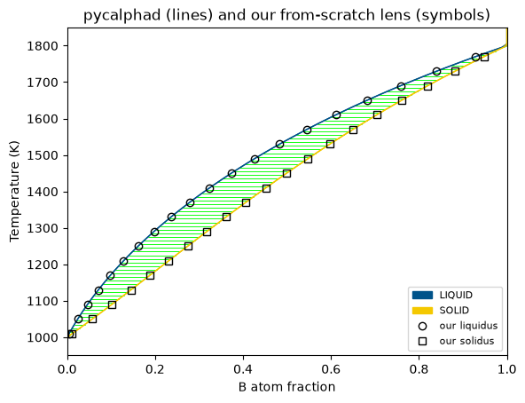

```python
ax = binplot(db, ["A", "B"], ["SOLID", "LIQUID"],
             {v.X("B"): (0, 1, 0.02), v.T: (950, 1850, 10), v.P: 100000, v.N: 1})
# lens[::4, 2]: every 4th row, column 2 (x_L); mfc="none" draws open symbols
ax.plot(lens[::4, 2], lens[::4, 0], "o", mfc="none", color="k", label="our liquidus")
ax.plot(lens[::4, 1], lens[::4, 0], "s", mfc="none", color="k", label="our solidus")
ax.set(title="pycalphad (lines) and our from-scratch lens (symbols)", xlabel="B atom fraction")
phase_legend = ax.get_legend()                                  # the legend binplot made: one colour per phase
handles = list(phase_legend.legend_handles) + ax.get_lines()[-2:]   # its entries plus our two symbol series
labels = [t.get_text() for t in phase_legend.get_texts()] + ["our liquidus", "our solidus"]
ax.legend(handles, labels, fontsize=8, loc="lower right")       # one legend for both
plt.show()
```

```python
#@title After your attempt: check the key numbers against the course values
confirm(x_S, 0.440517, "Solidus composition at 1400 K", tol=1e-5)
confirm(x_L, 0.312410, "Liquidus composition at 1400 K", tol=1e-5)
confirm(pyc["SOLID"][1], x_S, "SOLID composition from pycalphad (our value)", tol=1e-8)
confirm(pyc["LIQUID"][1], x_L, "LIQUID composition from pycalphad (our value)", tol=1e-8)
confirm(G_pycalphad, G_best, "G from pycalphad (our value)", tol=1e-6)
confirm(np.abs(lens[:, 1:] - exact).max(), 0.0, "Largest loop-minus-closed-form difference (zero)", tol=1e-9)
```

```
✓ Solidus composition at 1400 K reproduces the lesson value.
✓ Liquidus composition at 1400 K reproduces the lesson value.
✓ SOLID composition from pycalphad (our value) reproduces the lesson value.
✓ LIQUID composition from pycalphad (our value) reproduces the lesson value.
✓ G from pycalphad (our value) reproduces the lesson value.
✓ Largest loop-minus-closed-form difference (zero) reproduces the lesson value.
```

## 8. What pycalphad did for us

| Step | From scratch (this notebook) | In pycalphad |
| --- | --- | --- |
| Pure components | `g0`: h − T s by hand | `PARAMETER G(...)` lines in the TDB |
| Phase model | `g_phase`: weighted average + ideal mixing | phase and constituent lines; mixing added automatically |
| Global search | grid + `linprog` (section 5) | sampling of every phase, then the best combination |
| Exact answer | equal μ_A, μ_B with `fsolve` (section 4) | the equilibrium solver refines the candidates |
| Amounts | lever rule | `NP` in the result |
| Phase diagram | loop over T (section 6) | `binplot` |

For two ideal phases everything fits on a page. Real alloys add what makes a program worthwhile: many phases, interaction terms, magnetic contributions, several sublattices, ordering and more components. The steps stay the same: a model for g of every phase, a global search over phases and compositions, and equal chemical potentials at the end.

**Limits.** A and B are invented, and both phases are ideal, so the lens is the simplest possible two-phase diagram. Each calculation is a closed bulk sample at fixed T and p, with no interfaces, strain or kinetics: the diagram says which state has the lowest Gibbs energy, not how fast it forms.

Next: f5 · a binary in pycalphad, which reads a database with an interaction term and more of what `equilibrium` returns.